# Figures for Cord Blood MR1T Paper

#Save supplemental table 4

#Volcano plot for DEGs of Adult vs Cordblood

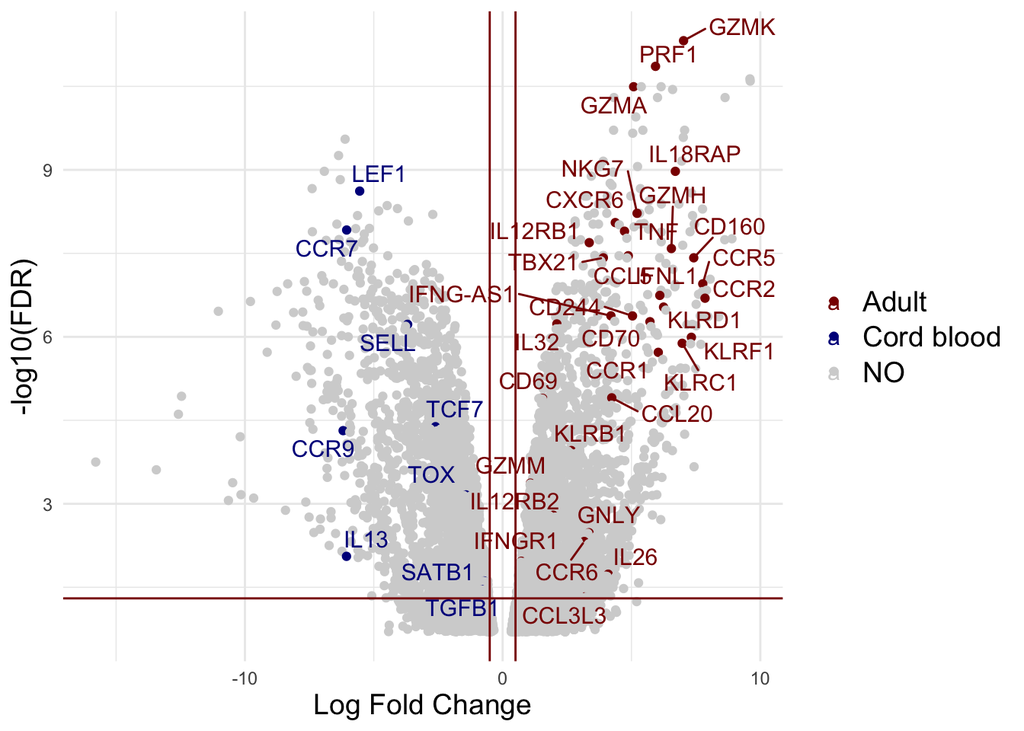

```r
DE_PBMC$diffexpressed <- "NO"
DE_PBMC$diffexpressed[DE_PBMC$logFC > 0.5 & DE_PBMC$FDR < 0.05
                      & DE_PBMC$gene %in% c("GZMK", "GZMA", "GNLY", "GZMM", "PRF1", "GNLY",  "GZMH", "CCR1", "CCR2", "CCR5", "CCR6", "CCL5", "CCL20", "CCL3L3", "CCL3", "CCL4", "CXCR6", "NKG7", "KLRF1", "KLRD1", "KLRC1", "KLRB1", "IL12RB1", "IL12RB2",  "IFNL1", "TNF", "IFNG-AS1", "IFNGR1", "IL18RAP",  "CD244", "CD70", "CD160", "IL26", "CD69", "IL32", "TBX21")
                      ] <- "Adult"
DE_PBMC$diffexpressed[DE_PBMC$logFC < -0.5 & DE_PBMC$FDR < 0.05
                      & DE_PBMC$gene %in% c("TGFB1", "SELL", "CCR7", "LEF1", "TCF7", "IL13", "SATB1", "CCR9", "TOX")
                      ] <- "Cord blood"

DE_PBMC$delabel <- NA
DE_PBMC$delabel[DE_PBMC$diffexpressed != "NO"] <- DE_PBMC$gene[DE_PBMC$diffexpressed != "NO"]

f1 <- DE_PBMC %>% ggplot(aes(logFC, -log10(FDR), col = diffexpressed, label = delabel)) + geom_point() + theme_minimal() + geom_text_repel(max.overlaps = 50, size = 4) + geom_vline(xintercept=c(-0.5, 0.5), col="dark red") +
    geom_hline(yintercept=-log10(0.05), col="dark red") + scale_color_manual(values = c("dark red", "dark blue", "light grey")) +
  theme(legend.title = element_blank(), legend.text = element_text(size = 14), axis.title.x = element_text(size = 14), axis.title.y = element_text(size = 14)) +
  labs(x = "Log Fold Change")
f1
```

#GO pathway analysis of DEGs from adults vs cord blood MR1T

[figure not shown]

```r
genes_up <- de_df[
  de_df$logFC >=0.5 & de_df$FDR < 0.05,"gene"]

genes_down <- de_df[
  de_df$logFC <=-0.5 & de_df$FDR < 0.05,"gene"]

#up in adult MR1T
enriched_go <- enrichr(c(genes_up), dbs_go)
enriched_pathway <- enrichr(c(genes_up), dbs_pathway)
g1 <- plotEnrich(enriched_go[[1]],
                 showTerms = 10,
                 numChar = 80,
                 y = "Ratio",
                 orderBy = "P.value") +
  theme(axis.text.y = element_text(size = 16),
        plot.title = element_text(size = 30),
        axis.title.y = element_blank(),
        axis.title.x = element_text(size = 14),
        legend.title = element_text(hjust = 0.5, size = 20),
        legend.text = element_text(size = 14)) +
  ggtitle("")

g1
```

#Figure 1f-g

#Figure 1h-i

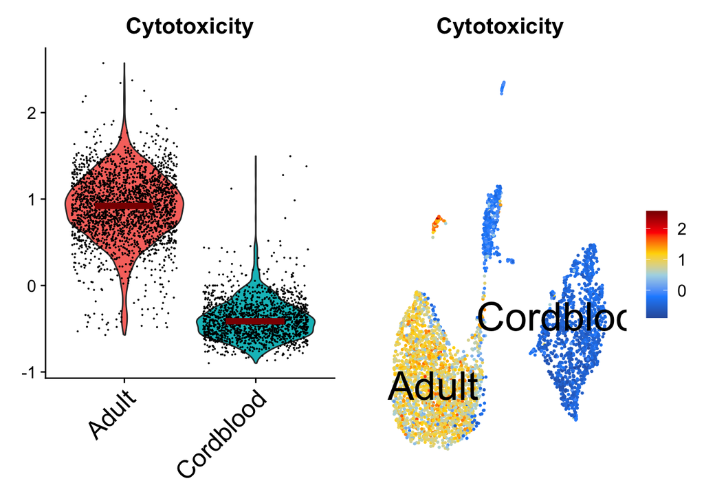

```r
seuratObj <- Seurat::AddModuleScore(seuratObj, features = list(RIRA::GetGeneSet("Cytotoxicity")), name = "MySignature", ctrl = 5)

seuratObj <- UCell::AddModuleScore_UCell(seuratObj, features = list("MySignature" = RIRA::GetGeneSet("Cytotoxicity")))

h1 <- VlnPlot(seuratObj,
              features = "MySignature1",
              group.by = "Donor")+
  stat_summary(fun.y = median,
               geom='point',
               size = 25,
               colour = "dark red",
               shape = 95) +
  theme(legend.position = 'none',
        axis.title.x = element_blank(),
        axis.text.x = element_text(size = 18)) +
  ggtitle("Cytotoxicity")

Idents(seuratObj) = "Donor"

i1 <- FeaturePlot(seuratObj,
                  features = "MySignature1",
                  label = TRUE,
                  label.color = "black",
                  label.size = 10) +
  ggtitle("Cytotoxicity") +
  theme(axis.text = element_blank(),
        axis.title = element_blank(),
        axis.line = element_blank(),
        axis.ticks = element_blank()) +
  scale_colour_gradientn(colours =
                           c("#2E5DAA", "dodgerblue", "lightblue", "gold", "red", "darkred"))


ggarrange(h1, i1, ncol = 2, nrow = 1)
```

#Getting statistics for cytotoxicity score

```r
ggbetweenstats(
  data  = seuratObj@meta.data[sample(1:nrow(seuratObj@meta.data), 3500),],
  x    = "Donor",
  y    = "Cytotoxicity_UCell",
  title = "Cytotoxicity across Donors"
)
```

[figure not shown]

#Supplemental Figure 2

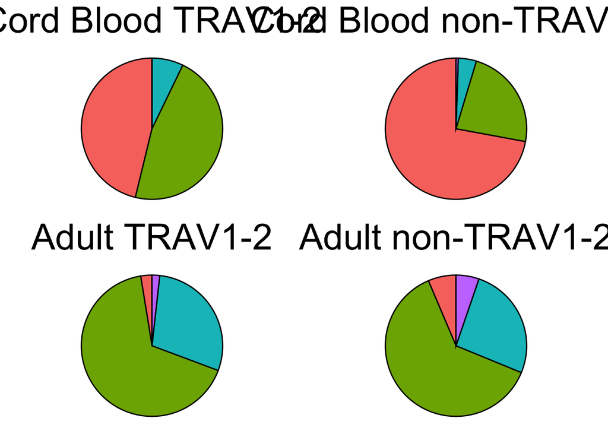

```r
CBTRAV <- df1 %>%
  filter(Donor == "Cordblood") %>%
  filter(TRAV == "TRAV1-2") %>%
  ggplot(aes(x = "", y = Frequency, fill = CD8)) +
  geom_bar(stat = "identity", width = 0.9, color = "black") +
  coord_polar("y", start = 0) +
  theme_void() +
  theme(legend.position = "none") +
  ggtitle("Cord Blood TRAV1-2") +
  theme(plot.title = element_text(hjust = 0.5, size = 30)) +
  guides(fill=guide_legend(override.aes=list(colour=NA)))

CBnTRAV <- df1 %>%
  filter(Donor == "Cordblood") %>%
  filter(TRAV == "non-TRAV1-2") %>%
  ggplot(aes(x = "", y = Frequency, fill = CD8)) +
  geom_bar(stat = "identity", width = 0.9, color = "black") +
  coord_polar("y", start = 0) +
  theme_void() +
  theme(legend.position = "none") +
  ggtitle("Cord Blood non-TRAV1-2") +
  theme(plot.title = element_text(hjust = 0.5, size = 30)) +
  guides(fill=guide_legend(override.aes=list(colour=NA)))

ATRAV <- df1 %>%
  filter(Donor == "Adult") %>%
  filter(TRAV == "TRAV1-2") %>%
  ggplot(aes(x = "", y = Frequency, fill = CD8)) +
  geom_bar(stat = "identity", width = 0.9, color = "black") +
  coord_polar("y", start = 0) +
  theme_void() +
  theme(legend.position = "none") +
  ggtitle("Adult TRAV1-2") +
  theme(plot.title = element_text(hjust = 0.5, size = 30)) +
  guides(fill=guide_legend(override.aes=list(colour=NA)))

AnTRAV <- df1 %>%
  filter(Donor == "Adult") %>%
  filter(TRAV == "non-TRAV1-2") %>%
  ggplot(aes(x = "", y = Frequency, fill = CD8)) +
  geom_bar(stat = "identity", width = 0.9, color = "black") +
  coord_polar("y", start = 0) +
  theme_void() +
  theme(legend.position = "none") +
  ggtitle("Adult non-TRAV1-2") +
  theme(plot.title = element_text(hjust = 0.5, size = 30)) +
  guides(fill=guide_legend(override.aes=list(colour=NA)))

ggarrange(CBTRAV, CBnTRAV, ATRAV, AnTRAV, ncol = 2, nrow = 2)
```

#Figure 2 - Cord blood TCR Diversity ##Making TRAV1-2,TRAV Column for dual alpha expressing MR1T cells

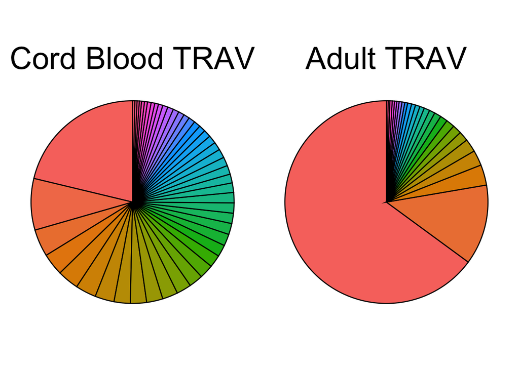

```r
meta_CB <- meta %>%
  filter(Donor == "Cordblood")
p1 <- data.frame(sort(table(meta_CB$TRA_V), decreasing = T))
rownames(p1) <- p1$Var1
p1$TRAV <- p1$Var1
p1$TRAV <- ifelse(p1$TRAV %in% c("TRAV1-1,TRAV1-2", "TRAV1-2,TRAV10", "TRAV1-2,TRAV12-1", "TRAV1-2,TRAV12-2", "TRAV1-2,TRAV12-3", "TRAV1-2,TRAV12-3,TRAV26-2", "TRAV1-2,TRAV13-1", "TRAV1-2,TRAV13-2",  "TRAV1-2,TRAV16", "TRAV1-2,TRAV17", "TRAV1-2,TRAV14/DV4", "TRAV1-2,TRAV14/DV4,TRAV26-2", "TRAV1-2,TRAV19", "TRAV1-2,TRAV2", "TRAV1-2,TRAV20", "TRAV1-2,TRAV21", "TRAV1-2,TRAV23/DV6", "TRAV1-2,TRAV25", "TRAV1-2,TRAV26-1", "TRAV1-2,TRAV26-2", "TRAV1-2,TRAV29/DV5", "TRAV1-2,TRAV3", "TRAV1-2,TRAV39", "TRAV1-2,TRAV4", "TRAV1-2,TRAV5", "TRAV1-2,TRAV6", "TRAV1-2,TRAV8-1", "TRAV1-2,TRAV8-2", "TRAV1-2,TRAV8-3", "TRAV1-2,TRBV8-4", "TRAV1-2,TRAV8-6", "TRAV1-2,TRAV9-2"), "TRAV1-2,TRAV", rownames(p1))


p1 <- p1 %>%
  group_by(TRAV) %>%
  summarise(Freq = sum(Freq))
p1 <- p1[order(p1$Freq, decreasing = T), ]

p2 <- p1 %>%
  filter(Freq > 2)

ga <- p2 %>%
  ggplot(aes(x = "", y = Freq, fill = reorder(TRAV, -Freq))) +
  geom_bar(stat = "identity", width = 0.9, color = "black") +
  coord_polar("y", start = 0) +
  theme_void() +
  theme(legend.position = "none") +
  ggtitle("Cord Blood TRAV") +
  theme(plot.title = element_text(hjust = 0.5, size = 30)) +
  guides(fill=guide_legend(override.aes=list(colour=NA)))

meta_A <- meta %>%
  filter(Donor == "Adult")
p3 <- data.frame(sort(table(meta_A$TRA_V), decreasing = T))

rownames(p3) <- p3$Var1
p3$TRAV <- p3$Var1
p3$TRAV <- ifelse(p3$TRAV %in% c("TRAV1-1,TRAV1-2", "TRAV1-2,TRAV10", "TRAV1-2,TRAV12-1", "TRAV1-2,TRAV12-2", "TRAV1-2,TRAV12-3", "TRAV1-2,TRAV12-3,TRAV26-2", "TRAV1-2,TRAV13-1", "TRAV1-2,TRAV13-2",  "TRAV1-2,TRAV16", "TRAV1-2,TRAV17", "TRAV1-2,TRAV14/DV4", "TRAV1-2,TRAV14/DV4,TRAV26-2", "TRAV1-2,TRAV19", "TRAV1-2,TRAV2", "TRAV1-2,TRAV20", "TRAV1-2,TRAV21", "TRAV1-2,TRAV23/DV6", "TRAV1-2,TRAV25", "TRAV1-2,TRAV26-1", "TRAV1-2,TRAV26-2", "TRAV1-2,TRAV29/DV5", "TRAV1-2,TRAV3", "TRAV1-2,TRAV39", "TRAV1-2,TRAV4", "TRAV1-2,TRAV5", "TRAV1-2,TRAV6", "TRAV1-2,TRAV8-1", "TRAV1-2,TRAV8-2", "TRAV1-2,TRAV8-3", "TRAV1-2,TRBV8-4", "TRAV1-2,TRAV8-6", "TRAV1-2,TRAV9-2"), "TRAV1-2,TRAV", rownames(p3))


p3 <- p3 %>%
  group_by(TRAV) %>%
  summarise(Freq = sum(Freq))

p3 <- p3[order(p3$Freq, decreasing = T), ]

p4 <- p3 %>%
  filter(Freq > 2)

g2 <- p4 %>%
  ggplot(aes(x = "", y = Freq, fill = reorder(TRAV, -Freq))) +
  geom_bar(stat = "identity", width = 0.9) +
  coord_polar("y", start = 0) +
  theme_void() +
  theme(legend.position = "none") +
  ggtitle("Adult TRAV") +
  theme(plot.title = element_text(hjust = 0.5, size = 30))+
  geom_bar(stat="identity", color='black') +
  guides(fill=guide_legend(override.aes=list(colour=NA)))

ga | g2
```

#TRAJ

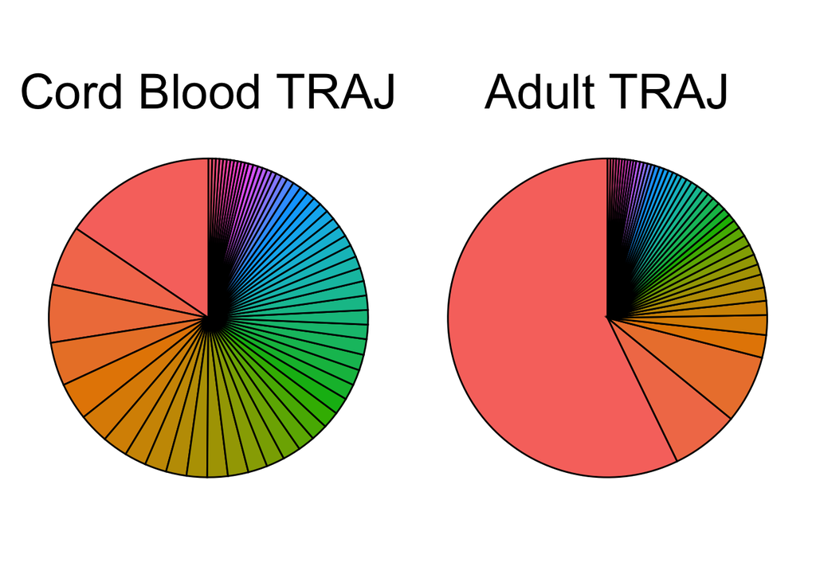

```r
meta_CB <- meta %>%
  filter(Donor == "Cordblood")
j1 <- data.frame(sort(table(meta_CB$TRA_J), decreasing = T))
j2 <- j1 %>%
  filter(Freq > 2)

g3 <- j2 %>%
  ggplot(aes(x = "", y = Freq, fill = Var1)) +
  geom_bar(stat = "identity", width = 0.9) +
  coord_polar("y", start = 0) +
  theme_void() +
  theme(legend.position = "none") +
  ggtitle("Cord Blood TRAJ") +
  theme(plot.title = element_text(hjust = 0.5, size = 30))+
  geom_bar(stat="identity", color='black') +
  guides(fill=guide_legend(override.aes=list(colour=NA)))

meta_A <- meta %>%
  filter(Donor == "Adult")
j3 <- data.frame(sort(table(meta_A$TRA_J), decreasing = T))
j4 <- j3 %>%
  filter(Freq > 2)

g4 <- j4 %>%
  ggplot(aes(x = "", y = Freq, fill = Var1)) +
  geom_bar(stat = "identity", width = 0.9) +
  coord_polar("y", start = 0) +
  theme_void() +
  theme(legend.position = "none") +
  ggtitle("Adult TRAJ") +
  theme(plot.title = element_text(hjust = 0.5, size = 30))+
  geom_bar(stat="identity", color='black') +
  guides(fill=guide_legend(override.aes=list(colour=NA)))

g3 | g4
```

#CDR3a

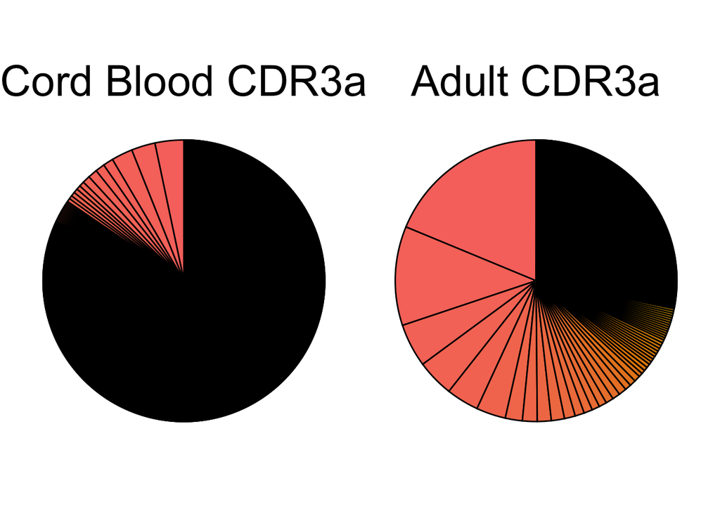

```r
meta_CB <- meta %>%
  filter(Donor == "Cordblood")
ca1 <- data.frame(sort(table(meta_CB$TRA), decreasing = T))
ca2 <- ca1 %>%
  filter(Freq > 0)

g5 <- ca2 %>%
  ggplot(aes(x = "", y = Freq, fill = Var1)) +
  geom_bar(stat = "identity", width = 0.9) +
  coord_polar("y", start = 0) +
  theme_void() +
  theme(legend.position = "none") +
  ggtitle("Cord Blood CDR3a") +
  theme(plot.title = element_text(hjust = 0.5, size = 30))+
  geom_bar(stat="identity", color='black') +
  guides(fill=guide_legend(override.aes=list(colour=NA)))

meta_A <- meta %>%
  filter(Donor == "Adult")
ca3 <- data.frame(sort(table(meta_A$TRA), decreasing = T))
ca4 <- ca3 %>%
  filter(Freq > 0)

g6 <- ca4 %>%
  ggplot(aes(x = "", y = Freq, fill = Var1)) +
  geom_bar(stat = "identity", width = 0.9, color = "black") +
  coord_polar("y", start = 0) +
  theme_void() +
  theme(legend.position = "none") +
  ggtitle("Adult CDR3a") +
  theme(plot.title = element_text(hjust = 0.5, size = 30)) +
  guides(fill=guide_legend(override.aes=list(colour=NA)))

g5 | g6
```

#TRBV

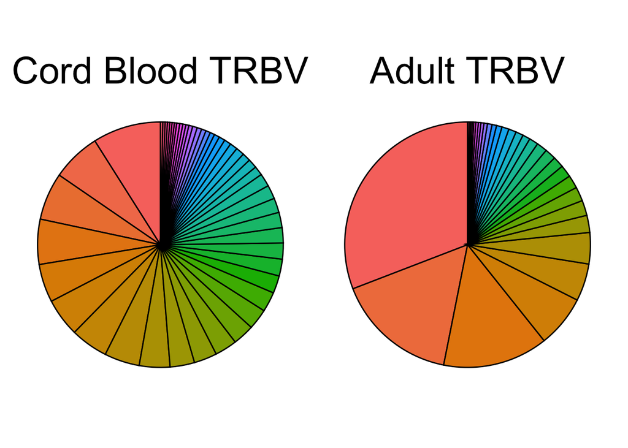

```r
meta_CB <- meta %>%
  filter(Donor == "Cordblood")
b1 <- data.frame(sort(table(meta_CB$TRB_V), decreasing = T))
b2 <- b1 %>%
  filter(Freq > 2)

g7 <- b2 %>%
  ggplot(aes(x = "", y = Freq, fill = Var1)) +
  geom_bar(stat = "identity", width = 0.9, color = "black") +
  coord_polar("y", start = 0) +
  theme_void() +
  theme(legend.position = "none") +
  ggtitle("Cord Blood TRBV") +
  theme(plot.title = element_text(hjust = 0.5, size = 30))+
  guides(fill=guide_legend(override.aes=list(colour=NA)))

meta_A <- meta %>%
  filter(Donor == "Adult")
b3 <- data.frame(sort(table(meta_A$TRB_V), decreasing = T))
b4 <- b3 %>%
  filter(Freq > 2)

g8 <- b4 %>%
  ggplot(aes(x = "", y = Freq, fill = Var1)) +
  geom_bar(stat = "identity", width = 0.9, color = "black") +
  coord_polar("y", start = 0) +
  theme_void() +
  theme(legend.position = "none") +
  ggtitle("Adult TRBV") +
  theme(plot.title = element_text(hjust = 0.5, size = 30)) +
  guides(fill=guide_legend(override.aes=list(colour=NA)))

g7 | g8
```

#Figure 2a-f

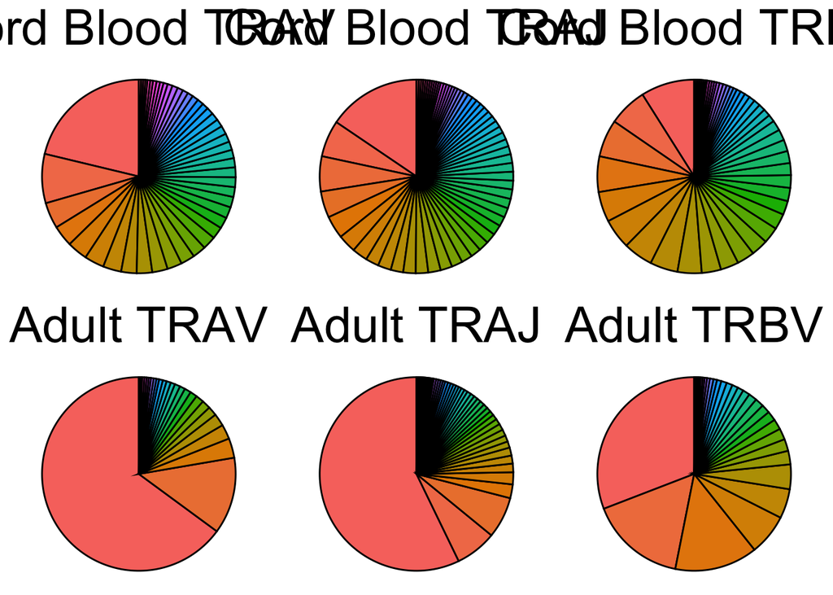

```r
Figure2 <- ggarrange(ga, g3, g7, g2, g4, g8, ncol = 3, nrow = 2)
Figure2
```

#Figure 2 g-i ##Below code gives tables and then manually copied into prism to graph

#TRA

```r
#TRA
df <- meta %>%
  filter(!is.na(TRA)) %>%
  subset(select = c(SubjectId, TRA))

df1 <- data.frame(table(df$SubjectId, df$TRA))
df1 <- df1 %>% filter(Freq > 0)

df1 %>%
  group_by(Var1) %>%
  summarize(sobs = richness(Freq),
            shannon = shannon(Freq),
            simpson = simpson(Freq),
            invsimpson = 1/simpson(Freq),
            n = sum(Freq))
```

# A tibble: 10 × 6

Var1 sobs shannon simpson invsimpson n 1 CB1016 29 3.32 0.0968 10.3 32 2 CB1029 192 5.26 0 Inf 192 3 CB1034 445 5.95 0.107 9.38 498 4 CB964 Tet+ 18 2.32 0.605 1.65 44 5 CB982 210 5.07 0.196 5.10 261 6 D427 Tet+ 69 3.45 0.700 1.43 228 7 D518 Tet+ 52 3.18 0.622 1.61 136 8 D520 Tet+ 99 3.69 0.610 1.64 252 9 D719 Tet+ 66 3.51 0.496 2.02 130 10 D777 Tet+ 107 3.60 0.720 1.39 379

#TRAJ

```r
#TRAJ
df <- meta %>%
  filter(!is.na(TRA_J)) %>%
  subset(select = c(SubjectId, TRA_J))

df1 <- data.frame(table(df$SubjectId, df$TRA_J))
df1 <- df1 %>% filter(Freq > 0)

df1 %>%
  group_by(Var1) %>%
  summarize(sobs = richness(Freq),
            shannon = shannon(Freq),
            simpson = simpson(Freq),
            invsimpson = 1/simpson(Freq),
            n = sum(Freq))
```

# A tibble: 10 × 6

Var1 sobs shannon simpson invsimpson n 1 CB1016 23 2.98 0.241 4.14 30 2 CB1029 78 4.08 0.582 1.72 185 3 CB1034 147 4.29 0.701 1.43 489 4 CB964 Tet+ 15 2.14 0.65 1.54 41 5 CB982 94 3.70 0.632 1.58 254 6 D427 Tet+ 40 2.38 0.827 1.21 226 7 D518 Tet+ 30 1.70 0.780 1.28 133 8 D520 Tet+ 45 1.93 0.823 1.22 249 9 D719 Tet+ 29 1.89 0.778 1.29 127 10 D777 Tet+ 43 2.24 0.886 1.13 368

#TRBV

```r
#TRBV
df <- meta %>%
  filter(!is.na(TRB_V)) %>%
  subset(select = c(SubjectId, TRB_V))

df1 <- data.frame(table(df$SubjectId, df$TRB_V))
df1 <- df1 %>% filter(Freq > 0)

df1 %>%
  group_by(Var1) %>%
  summarize(sobs = richness(Freq),
            shannon = shannon(Freq),
            simpson = simpson(Freq),
            invsimpson = 1/simpson(Freq),
            n = sum(Freq))
```

# A tibble: 10 × 6

Var1 sobs shannon simpson invsimpson n 1 CB1016 28 3.29 0.156 6.4 33 2 CB1029 71 3.77 0.676 1.48 217 3 CB1034 121 3.91 0.778 1.29 541 4 CB964 Tet+ 29 3.11 0.659 1.52 83 5 CB982 78 3.75 0.717 1.39 273 6 D427 Tet+ 23 1.88 0.929 1.08 309 7 D518 Tet+ 27 2.53 0.854 1.17 179 8 D520 Tet+ 46 2.71 0.872 1.15 353 9 D719 Tet+ 35 2.56 0.826 1.21 196 10 D777 Tet+ 50 2.60 0.911 1.10 550

#TRB

```r
#TRB
df <- meta %>%
  filter(!is.na(TRB)) %>%
  subset(select = c(SubjectId, TRB))

df1 <- data.frame(table(df$SubjectId, df$TRB))
df1 <- df1 %>% filter(Freq > 0)

df1 %>%
  group_by(Var1) %>%
  summarize(sobs = richness(Freq),
            shannon = shannon(Freq),
            simpson = simpson(Freq),
            invsimpson = 1/simpson(Freq),
            n = sum(Freq))
```

# A tibble: 10 × 6

Var1 sobs shannon simpson invsimpson n 1 CB1016 33 3.50 0 Inf 33 2 CB1029 217 5.38 0 Inf 217 3 CB1034 538 6.29 0.00556 180 541 4 CB964 Tet+ 79 4.32 0.0488 20.5 83 5 CB982 273 5.61 0 Inf 273 6 D427 Tet+ 100 3.91 0.679 1.47 309 7 D518 Tet+ 121 4.50 0.326 3.07 179 8 D520 Tet+ 215 4.91 0.392 2.55 353 9 D719 Tet+ 133 4.60 0.323 3.10 196 10 D777 Tet+ 240 4.81 0.565 1.77 550

#TRBJ

```r
#TRBJ
df <- meta %>%
  filter(!is.na(TRB_J)) %>%
  subset(select = c(SubjectId, TRB_J))

df1 <- data.frame(table(df$SubjectId, df$TRB_J))
df1 <- df1 %>% filter(Freq > 0)

df1 %>%
  group_by(Var1) %>%
  summarize(sobs = richness(Freq),
            shannon = shannon(Freq),
            simpson = simpson(Freq),
            invsimpson = 1/simpson(Freq),
            n = sum(Freq))
```

# A tibble: 10 × 6

Var1 sobs shannon simpson invsimpson n 1 CB1016 21 2.79 0.375 2.67 33 2 CB1029 39 3.00 0.823 1.21 216 3 CB1034 72 3.17 0.866 1.16 529 4 CB964 Tet+ 16 2.33 0.812 1.23 81 5 CB982 38 2.93 0.861 1.16 268 6 D427 Tet+ 19 2.10 0.942 1.06 309 7 D518 Tet+ 16 2.19 0.908 1.10 164 8 D520 Tet+ 30 2.52 0.907 1.10 313 9 D719 Tet+ 33 2.70 0.824 1.21 183 10 D777 Tet+ 37 2.47 0.933 1.07 541

#Supplemental Figure 4 - TRAV Surface Expression

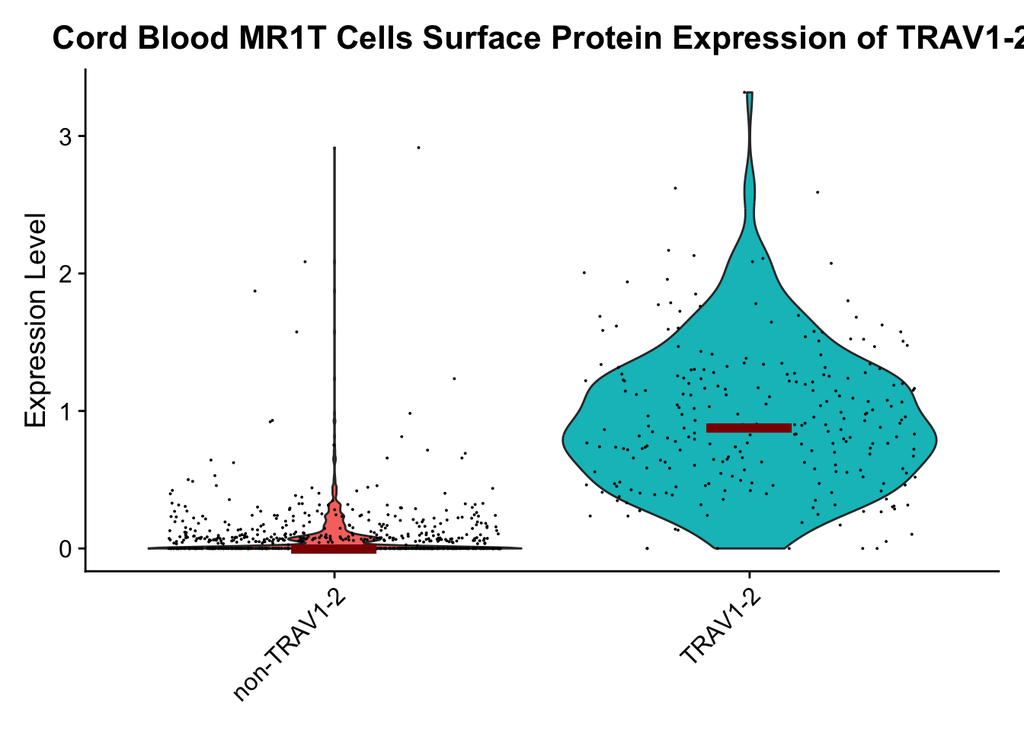

```r
seuratObjCB = subset(seuratObj, Donor == "Cordblood")
seuratObjCBTCR = subset(seuratObjCB, TRAV %in% c("non-TRAV1-2", "TRAV1-2"))

Supplemental4 <- VlnPlot(seuratObjCBTCR, features = "adt_TCR-Va7.2", group.by = "TRAV") +
  stat_summary(fun.y = median, geom='point', size = 25, colour = "dark red", shape = 95) +
  theme(legend.position = 'none') +
  ggtitle("Cord Blood MR1T Cells Surface Protein Expression of TRAV1-2") +
  theme(axis.title.x = element_blank())

Supplemental4
```

#Supplemental - not shown. TRAJ usage of TRAV1-2 Positive vs Negative

#Figure 3D - DEGs of TRAV1-2+ vs non-TRAV1-2

#GO pathways for DEGs between TRAV1-2+ and non-TRAV1-2 (not included in paper)

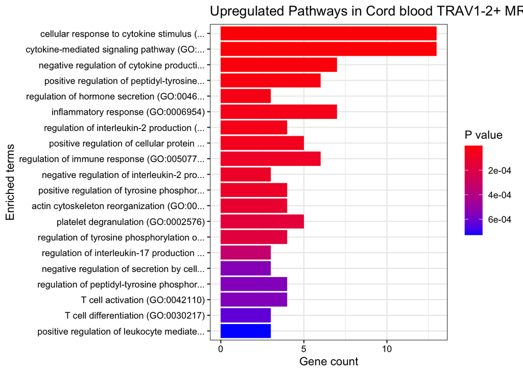

```r
de_df$gene <- rownames(de_df)

genes_up <- de_df[
  de_df$avg_log2FC >=0.5 & de_df$p_val_adj < 0.05,"gene"]

genes_down <- de_df[
  de_df$avg_log2FC <=-0.5 & de_df$p_val_adj < 0.05,"gene"]

enriched_go <- enrichr(c(genes_up), dbs_go)
enriched_pathway <- enrichr(c(genes_up), dbs_pathway)
plotEnrich(enriched_go[[1]], showTerms = 20, numChar = 40, y = "Count", orderBy = "P.value") + ggtitle("Upregulated Pathways in Cord blood TRAV1-2+ MR1T Cells")
```

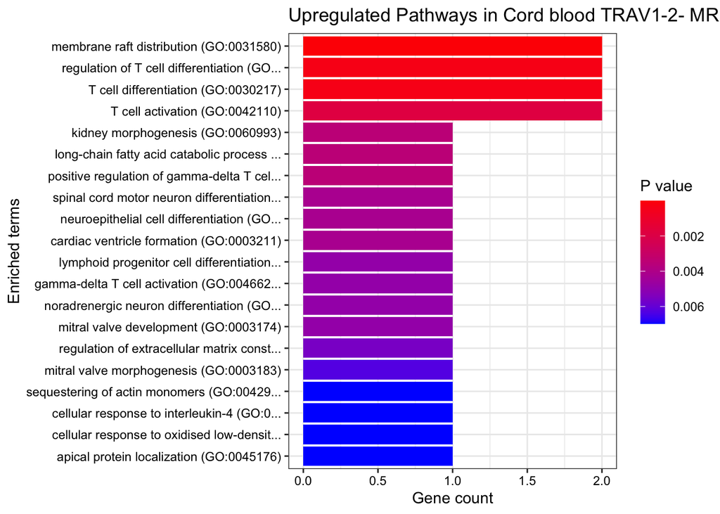

```r
p1 <- plotEnrich(enriched_go[[1]], showTerms = 20, numChar = 40, y = "Count", orderBy = "P.value") + ggtitle("Upregulated Pathways in Cord blood TRAV1-2+ MR1T Cells")

enriched_go <- enrichr(c(genes_down), dbs_go)
enriched_pathway <- enrichr(c(genes_down), dbs_pathway)
plotEnrich(enriched_go[[1]], showTerms = 20, numChar = 40, y = "Count", orderBy = "P.value") + ggtitle("Upregulated Pathways in Cord blood TRAV1-2- MR1T Cells")
```

```r
p2 <- plotEnrich(enriched_go[[1]], showTerms = 20, numChar = 40, y = "Count", orderBy = "P.value") + ggtitle("Upregulated Pathways in Cord Blood TRAV1-2- MR1T Cells")
```

#generating supplemental table 5

#Figure 3D - volcano plot of DEGs between TRAV1-2 and non-TRAV1-2 MR1Ts

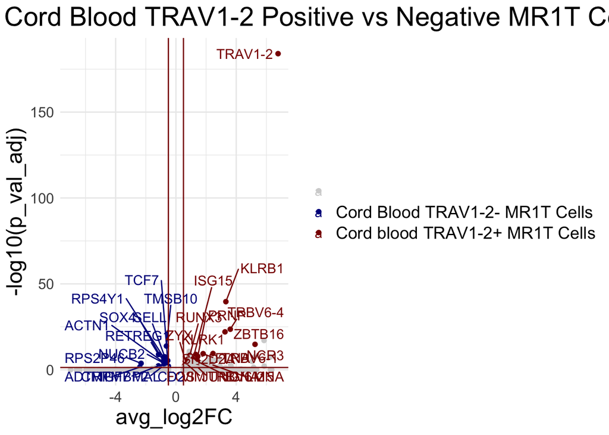

```r
#Volcano Plot
DE_PBMC$diffexpressed <- ""
DE_PBMC$diffexpressed[DE_PBMC$avg_log2FC > 0.5 & DE_PBMC$p_val_adj < 0.05
                      & DE_PBMC$gene %in% c("TRAV1-2", "KLRB1", "NCR3", "TRBV6-1", "TRBV6-2", "TRBV6-4", "LMNA", "ANXA1", "GNA15", "SH2D2A", "RUNX3", "VIM", "PRNP", "KLRK1", "CSRNP1", "JUND", "FLNA", "ISG15", "ZBTB16", "FOS", "ZYX")
                      ] <- "Cord blood TRAV1-2+ MR1T Cells"
DE_PBMC$diffexpressed[DE_PBMC$avg_log2FC < -0.5 & DE_PBMC$p_val_adj < 0.05
                      #& DE_PBMC$gene %in% c()
                        ] <- "Cord Blood TRAV1-2- MR1T Cells"

DE_PBMC$delabel <- NA
DE_PBMC$delabel[DE_PBMC$diffexpressed != ""] <- DE_PBMC$gene[DE_PBMC$diffexpressed != ""]

Fig3D <- DE_PBMC %>% ggplot(aes(avg_log2FC, -log10(p_val_adj), col = diffexpressed, label = delabel)) + geom_point() + theme_minimal() + geom_text_repel(max.overlaps = 50, size = 4) + geom_vline(xintercept=c(-0.5, 0.5), col="dark red") +
    geom_hline(yintercept=-log10(0.05), col="dark red") + scale_color_manual(values = c("light grey", "dark blue", "dark red"))+ggtitle("Differential Expression of Cord Blood TRAV1-2 Positive vs Negative MR1T Cells") +
  theme(legend.title = element_blank(),
        axis.text = element_text(size = 12),
        axis.title.x = element_text(size = 18),
        axis.title.y = element_text(size = 18),
        legend.text = element_text(size = 14),
        plot.title = element_text(hjust = 0.5, size = 22))
Fig3D
```

#Supplemental Figure 5 - Difference in TRAV1-2+ Adult vs Cord blood

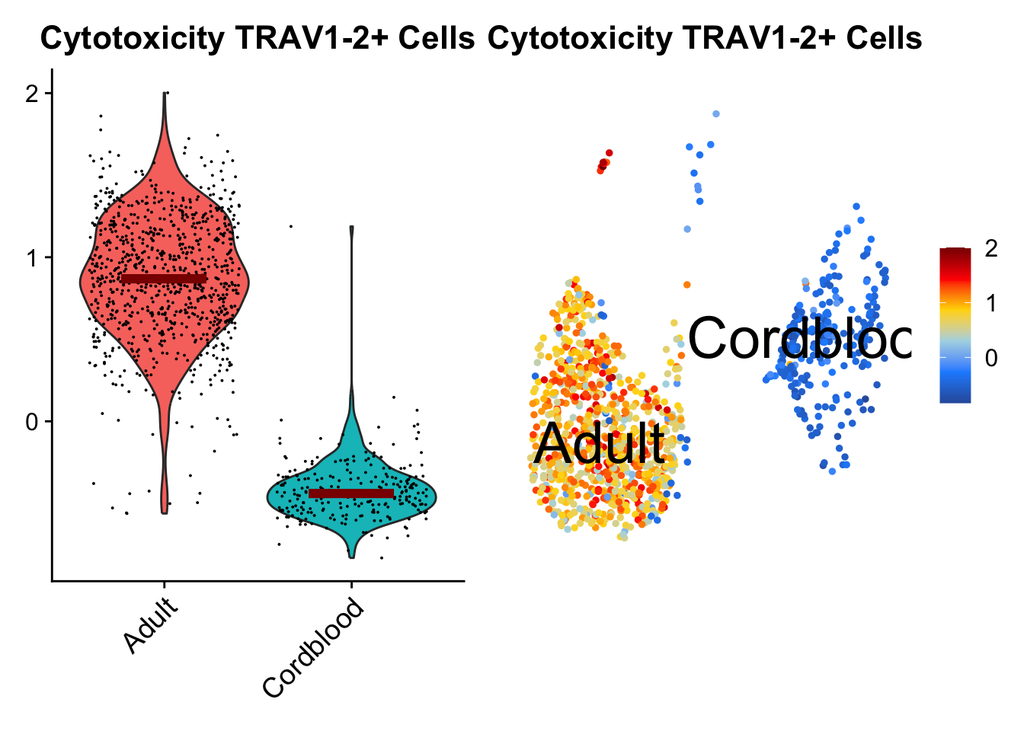

```r
seuratObjTRAVpos <-
  Seurat::AddModuleScore(seuratObjTRAVpos,
                                           features =
                           list(RIRA::GetGeneSet("Cytotoxicity")),
                         name = "MySignature", ctrl = 5)

seuratObjTRAVpos <- UCell::AddModuleScore_UCell(seuratObjTRAVpos,
                                                features =
                                                  list("MySignature" =
                                                      RIRA::GetGeneSet("Cytotoxicity")))

Sup5a <- VlnPlot(seuratObjTRAVpos,
                 features = "MySignature1",
                 group.by = "Donor")+
  stat_summary(fun.y = median,
               geom='point',
               size = 25,
               colour = "dark red",
               shape = 95)+
  theme(legend.position = 'none',
        axis.title.x = element_blank(),
        axis.text.x = element_text(size = 14)) +
  ggtitle("Cytotoxicity TRAV1-2+ Cells")

Idents(seuratObjTRAVpos) = "Donor"
Sup5b <- FeaturePlot(seuratObjTRAVpos,
                     features = "MySignature1",
                     label = TRUE,
                     label.color = "black",
                     label.size = 10) +
  ggtitle("Cytotoxicity TRAV1-2+ Cells") +
  theme(axis.text = element_blank(),
        axis.title = element_blank(),
        axis.line = element_blank(),
        axis.ticks = element_blank(),
        plot.title = element_text(hjust = 0.5)) +
  scale_colour_gradientn(colours =
                           c("#2E5DAA", "dodgerblue", "lightblue", "gold", "red", "darkred"))

Sup5a | Sup5b
```

#generate statistics for cytotoxicity score

```r
ggbetweenstats(
  data  = seuratObjTRAVpos@meta.data[sample(1:nrow(seuratObjTRAVpos@meta.data), 1100),],
  x    = "Donor",
  y    = "Cytotoxicity_UCell",
  title = "Cytotoxicity across Donors TRAV1-2+"
)
```

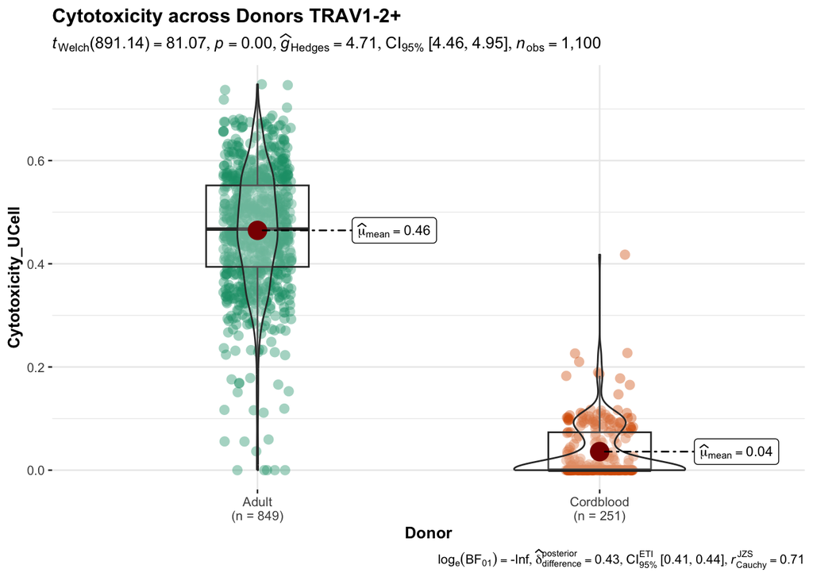

##Clone Analysis - second half of paper #Download seurat object for MR1T cell clones

# Download and append TCR

#Subset out cells included in study and add labels for donor type

#Re-cluster after subset

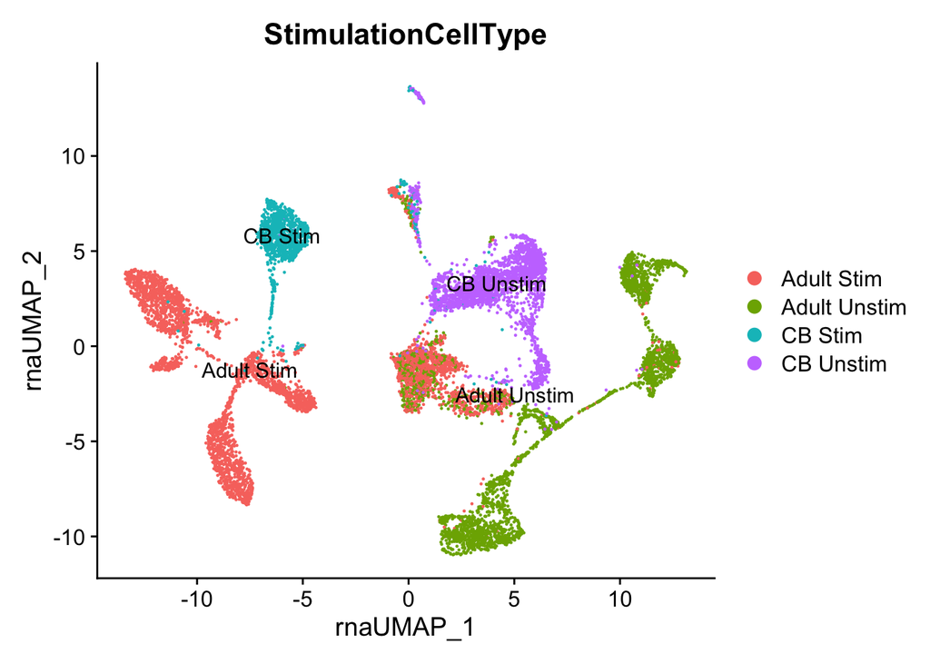

#Start here is seuratObj2 already saved

#Figure 5A-F

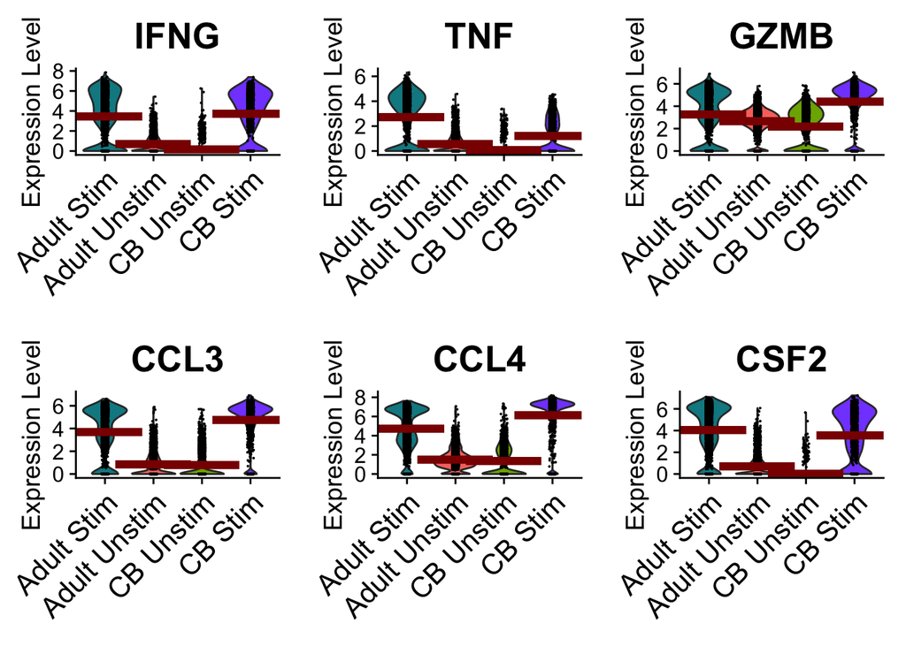

```r
Idents(seuratObj2) = "StimulationCellType"
my_levels <- c("Adult Unstim", "Adult Stim", "CB Unstim", "CB Stim")
seuratObj2@meta.data$StimulationCellType <- factor(x = seuratObj2@meta.data$StimulationCellType, levels = c("Adult Unstim", "Adult Stim", "CB Unstim", "CB Stim"))

IFNG <- VlnPlot(seuratObj2, features = c("IFNG"), split.by = "StimulationCellType") + stat_summary(fun.y = mean, geom='point', size = 25, colour = "dark red", shape = 95) + theme(legend.position = 'none') +
  theme(axis.title.x = element_blank(),
        axis.text.x = element_text(size = 16),
        plot.title = element_text(size = 20))

TNF <- VlnPlot(seuratObj2, features = c("TNF"), split.by = "StimulationCellType") +
  stat_summary(fun.y = mean, geom='point', size = 25, colour = "dark red", shape = 95) + theme(legend.position = 'none') +
  theme(axis.title.x = element_blank(),
        axis.text.x = element_text(size = 16),
        plot.title = element_text(size = 20))

GZMB <- VlnPlot(seuratObj2, features = c("GZMB"), split.by = "StimulationCellType") +
  stat_summary(fun.y = mean, geom='point', size = 25, colour = "dark red", shape = 95) + theme(legend.position = 'none') +
  theme(axis.title.x = element_blank(),
        axis.text.x = element_text(size = 16),
        plot.title = element_text(size = 20))

CCL3 <- VlnPlot(seuratObj2, features = c("CCL3"), split.by = "StimulationCellType") +
  stat_summary(fun.y = mean, geom='point', size = 25, colour = "dark red", shape = 95) + theme(legend.position = 'none') +
  theme(axis.title.x = element_blank(),
        axis.text.x = element_text(size = 16),
        plot.title = element_text(size = 20))

CCL4 <- VlnPlot(seuratObj2, features = c("CCL4"), split.by = "StimulationCellType") +
  stat_summary(fun.y = mean, geom='point', size = 25, colour = "dark red", shape = 95) + theme(legend.position = 'none') +
  theme(axis.title.x = element_blank(),
        axis.text.x = element_text(size = 16),
        plot.title = element_text(size = 20))

CSF2 <- VlnPlot(seuratObj2, features = c("CSF2"), split.by = "StimulationCellType") +
  stat_summary(fun.y = mean, geom='point', size = 25, colour = "dark red", shape = 95) + theme(legend.position = 'none') +
  theme(axis.title.x = element_blank(),
        axis.text.x = element_text(size = 16),
        plot.title = element_text(size = 20))

Fig5 <- ggarrange(IFNG, TNF, GZMB, CCL3, CCL4, CSF2)
Fig5
```

#Figure 5g-h pseudobulk analysis

#generating supplemental table 6

##Pathway analysis (not shown in paper)

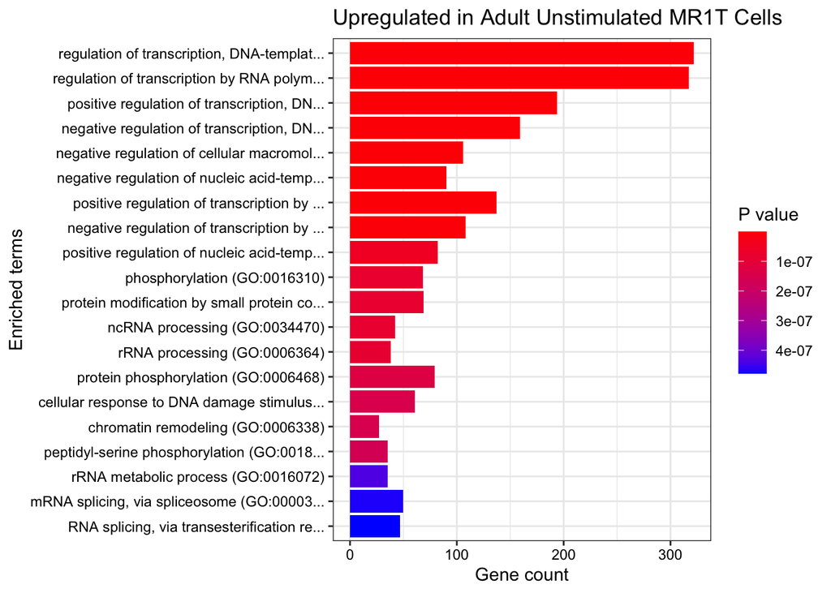

```r
genes_up <- DE_PBMC[
  DE_PBMC$logFC >=0.5 & DE_PBMC$FDR < 0.05,"gene"]

genes_down <- DE_PBMC[
  DE_PBMC$logFC <=-0.5 & DE_PBMC$FDR < 0.05,"gene"]

#Run to look at genes up in adult unstim
enriched_go <- enrichr(c(genes_up), dbs_go)
enriched_pathway <- enrichr(c(genes_up), dbs_pathway)
plotEnrich(enriched_go[[1]], showTerms = 20, numChar = 40, y = "Count", orderBy = "P.value") + ggtitle("Upregulated in Adult Unstimulated MR1T Cells")
```

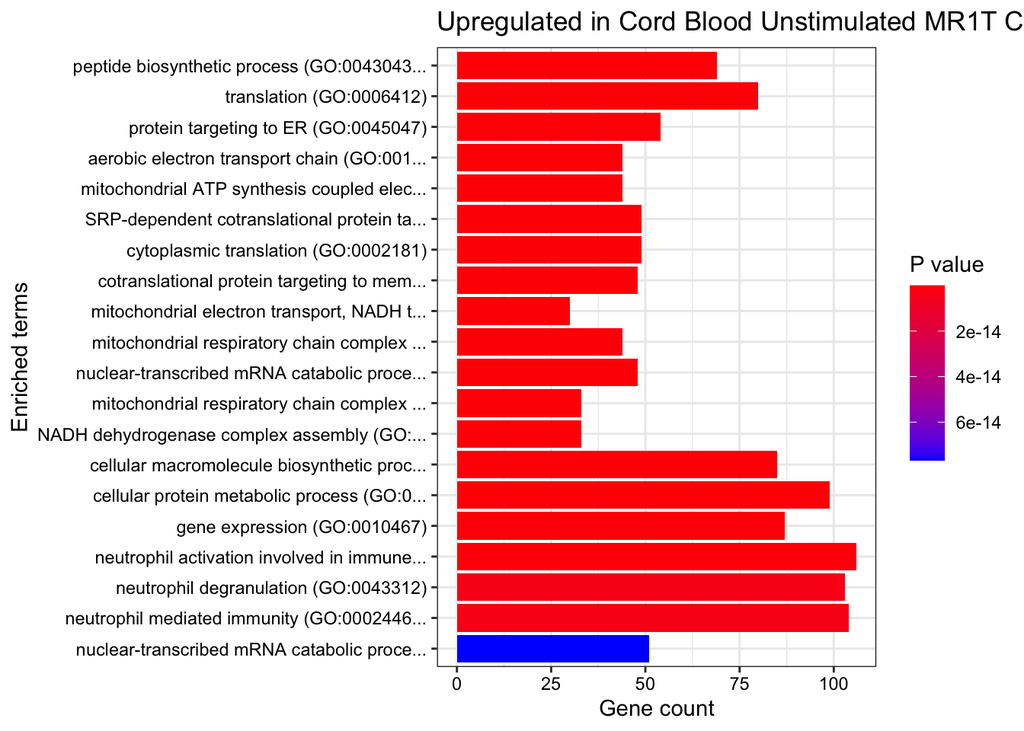

```r
#Run to look at genes up in cord blood unstim
enriched_go <- enrichr(c(genes_down), dbs_go)
enriched_pathway <- enrichr(c(genes_down), dbs_pathway)
plotEnrich(enriched_go[[1]], showTerms = 20, numChar = 40, y = "Count", orderBy = "P.value") + ggtitle("Upregulated in Cord Blood Unstimulated MR1T Cells")
```

##Volcano plot for DE of Unstimulated Adult vs Cordblood

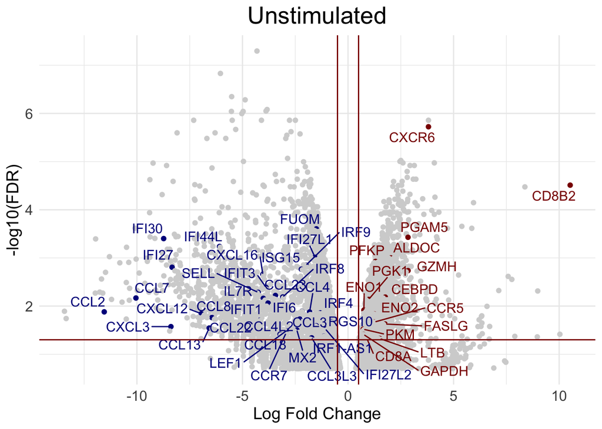

```r
DE_PBMC$diffexpressed <- ""
DE_PBMC$diffexpressed[DE_PBMC$logFC > 0.5 & DE_PBMC$FDR < 0.05
                      & DE_PBMC$gene %in% c("GZMH", "PRF1", "CD8A", "CD8B2", "CCR5", "CXCR6", "CXCR3", "LTB", "FASLG", "ENO1", "ENO2", "ALDOC", "GAPDH", "PFKP", "PGAM5", "PGK1", "PKM", "CEBPD")
                      ] <- "Adult Unstimulated"
DE_PBMC$diffexpressed[DE_PBMC$logFC < -0.5 & DE_PBMC$FDR < 0.05
                      & DE_PBMC$gene %in% c("SELL", "CCR7", "IL7R", "FUOM", "LEF1", "RGS10", "CCL3", "CCL3L3", "CCL4", "CCL4L2", "CCL23", "CCL18", "CCL1", "CCL22", "CCL24", "CCL8", "CCL13", "CCL7", "CCL2", "CXCL9", "CXCL12", "CXCL3", "CXCL16", "IFI30", "IFI27", "IFI44L", "IFIT3", "IFIT1", "IFI6", "IFI27L1", "IFI27L2", "ISG15", "MX2", "IRF4", "IRF9", "IRF8", "IRF1-AS1", "HERC5", "IFIT1", "IFIT3", "IL17C")
                      ] <- "Cord Blood Unstimulated"

DE_PBMC$delabel <- NA
DE_PBMC$delabel[DE_PBMC$diffexpressed != ""] <- DE_PBMC$gene[DE_PBMC$diffexpressed != ""]

a4 <- DE_PBMC %>% ggplot(aes(logFC, -log10(FDR), col = diffexpressed, label = delabel)) + geom_point() + theme_minimal() + geom_text_repel(max.overlaps = 50, size = 4) + geom_vline(xintercept=c(-0.5, 0.5), col="dark red") +
    geom_hline(yintercept=-log10(0.05), col="dark red") + scale_color_manual(values = c("light grey", "dark red", "dark blue"))+ggtitle("Unstimulated") + theme(legend.position = "none") + theme(plot.title = element_text(hjust = 0.5, size = 20), axis.title.x = element_text(size = 14),  axis.title.y = element_text(size = 14), legend.text = element_text(size = 14), axis.text = element_text(size = 12))  +
  labs(x = "Log Fold Change")
a4
```

#Adult Stim vs Cord Blood Stim

##Pathway analysis (not shown in paper)

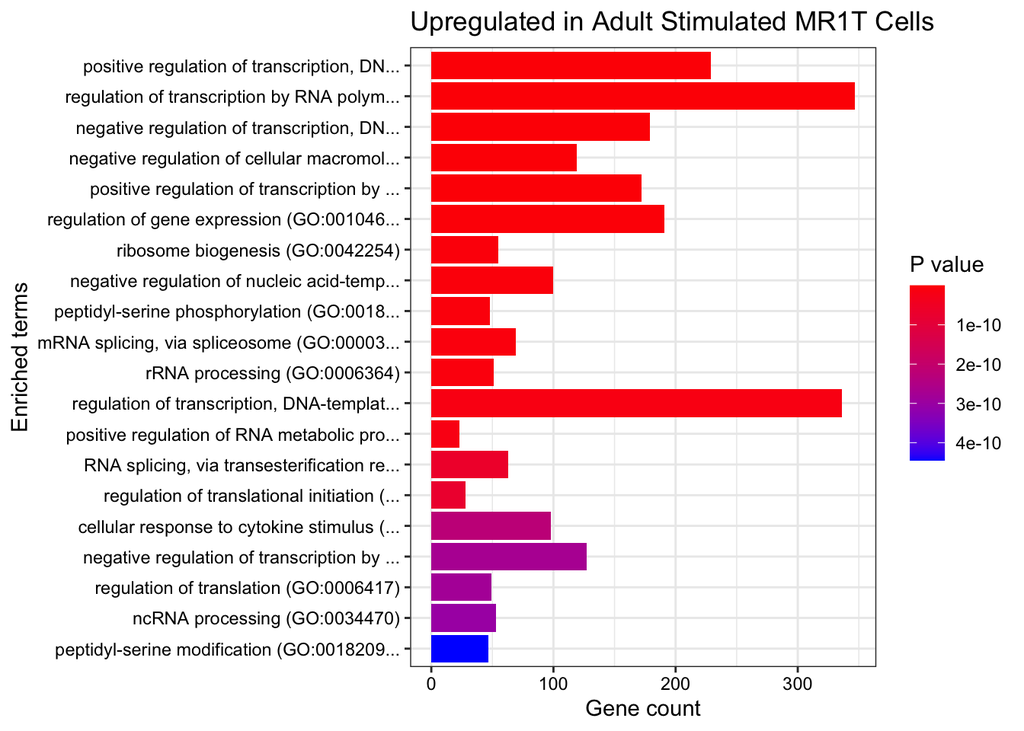

```r
genes_up <- DE_PBMC[
  DE_PBMC$logFC >=0.5 & DE_PBMC$FDR < 0.05,"gene"]

genes_down <- DE_PBMC[
  DE_PBMC$logFC <=-0.5 & DE_PBMC$FDR < 0.05,"gene"]

#Run to look at genes up in adult stim
enriched_go <- enrichr(c(genes_up), dbs_go)
enriched_pathway <- enrichr(c(genes_up), dbs_pathway)
plotEnrich(enriched_go[[1]], showTerms = 20, numChar = 40, y = "Count", orderBy = "P.value") + ggtitle("Upregulated in Adult Stimulated MR1T Cells")
```

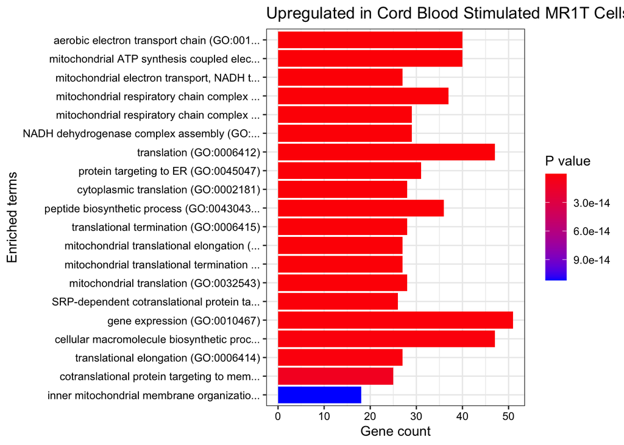

```r
#Run to look at genes up in cord blood stim
enriched_go <- enrichr(c(genes_down), dbs_go)
enriched_pathway <- enrichr(c(genes_down), dbs_pathway)
plotEnrich(enriched_go[[1]], showTerms = 20, numChar = 40, y = "Count", orderBy = "P.value") + ggtitle("Upregulated in Cord Blood Stimulated MR1T Cells")
```

#Save supplemental table 7

##Volcano plot for DE of Stimulated Adult vs Cordblood

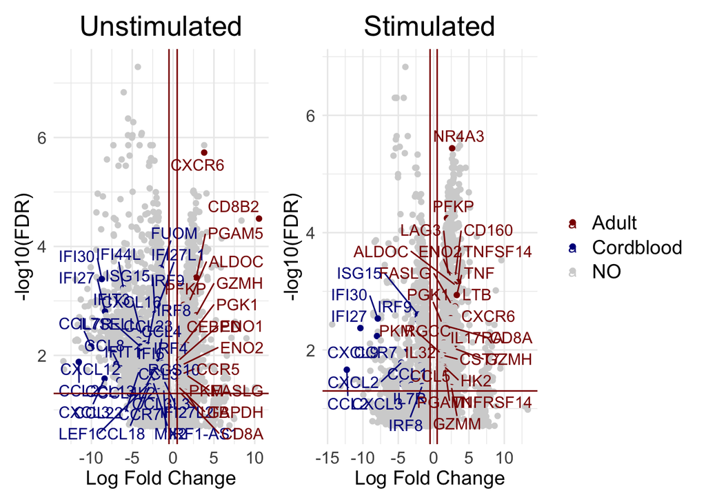

```r
DE_PBMC$diffexpressed <- "NO"
DE_PBMC$diffexpressed[DE_PBMC$logFC > 0.5 & DE_PBMC$FDR < 0.05
                      & DE_PBMC$gene %in% c("IL26", "GZMH", "GZMM", "GNLY", "LTB", "RGCC", "TNFSF14", "NR4A3", "FASLG", "TNF", "IL32", "IL17RA", "ALDOC", "ENO2", "HK2", "PGAM1", "PGK1", "PKM", "PFKP", "CTLA4", "HAVCR2", "LAG3", "CD244", "TNFRSF14", "CD160", "CST7", "CD8A", "CCL28", "CCL5", "CXCR6", "GZMM", "GZMH", "GNLY")
                      ] <- "Adult"
DE_PBMC$diffexpressed[DE_PBMC$logFC < -0.5 & DE_PBMC$FDR < 0.05
                      & DE_PBMC$gene %in% c("IFI30", "IFI27", "IFI6", "IFIT3", "ISG15", "IRF9", "IRF8", "MX1", "IL7R", "CCR7", "CCL1", "CCL7", "CCL2", "CXCL9", "CXCL2", "CXCL3", "CXCL16")
                      ] <- "Cordblood"

DE_PBMC$delabel <- NA
DE_PBMC$delabel[DE_PBMC$diffexpressed != "NO"] <- DE_PBMC$gene[DE_PBMC$diffexpressed != "NO"]

b4 <- DE_PBMC %>% ggplot(aes(logFC, -log10(FDR), col = diffexpressed, label = delabel)) + geom_point() + theme_minimal() + geom_text_repel(max.overlaps = 50, size = 4) + geom_vline(xintercept=c(-0.5, 0.5), col="dark red") +
    geom_hline(yintercept=-log10(0.05), col="dark red") + scale_color_manual(values = c("dark red", "dark blue", "light grey"))+ggtitle("Stimulated") + theme(plot.title = element_text(hjust = 0.5, size = 20), axis.title.x = element_text(size = 14),  axis.title.y = element_text(size = 14), legend.text = element_text(size = 14), legend.title = element_blank(), axis.text = element_text(size = 12)) +
  labs(x = "Log Fold Change")

Fig5GH <- a4 | b4
Fig5GH
```